# Advanced

Some users may prefer to use the [R code](https://github.com/leppott/ContDataQC) instead of the Shiny app. The example code in Figure 1 shows how to run the main functions when using the default settings in the R package. After the user directs R to the correct directories and selects the operation (QCRaw, Aggregate or SummaryStats), there are several places in the code where the user needs to make entries (e.g., SiteID, sensor type, and start/end date). R will read through the file names in the directory, select files that match the criteria and generate outputs for each input file that matches the criteria.

Users with intermediate to advanced-level R skills can customize the settings (e.g., add new parameters, change units, change file naming and formatting requirements, change the format of one of the QC reports from Word to html or PDF) by editing a plain text configuration file [ZIP]. Users have more flexibility using the Shiny app versus R package when it comes to setting directories and file naming schemes because they can browse to the desired input file(s).

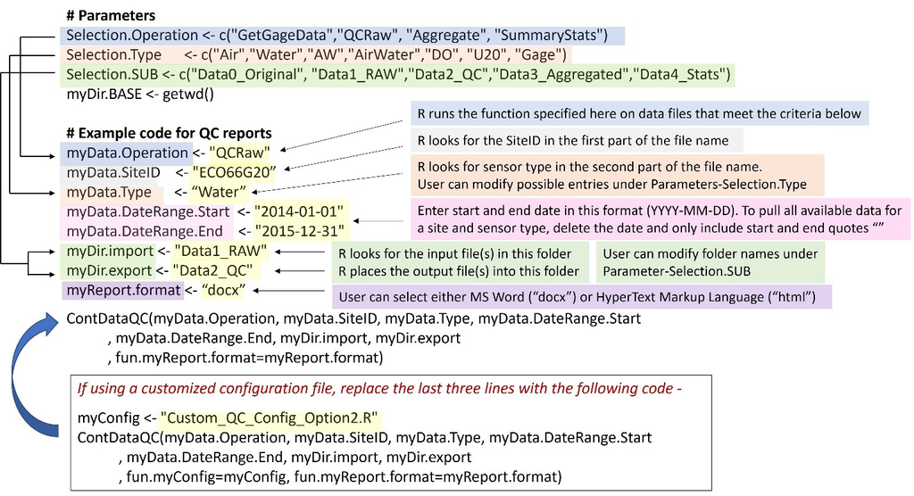

Figure 1. Example code from the ContDataQC R package for running the QCRaw function. Entries highlighted in yellow show places where users can modify entries. The other colors show where linkages exist between lines of code, with comments explaining how the R code uses each entry.